# Working with Data

- This lecture is suitable for undergraduate Python programming course or multidiciplinary postgraduate applied Data Science.
- The aim is to work with structured(tabular) data, such as CSV and excel sheets.
- Prerequisite:
  - Familiar with basic Python programming.
  - Jupyter Notebook is installed and configured.
  - Familiar with basic data structures such as lists.
  - To choose a dataset from Kaggle, UCI ML repository or any other available sources.

# Dataset Example

- Global Breast Cancer Mortality rate for the past 25 years for 7 different supper regions.
- Countries are different observations
- Super_Region, MR for different years are features.

```python
import pandas as pd
can_df = pd.read_csv("BC_clean.csv")
can_df.head(10)
```

|  | Location | Super_Region | 1990 | 1995 | 2000 | 2005 | 2010 | 2015 |
| --- | --- | --- | --- | --- | --- | --- | --- | --- |
| 0 | Afghanistan | North Africa and Middle East | 8.855529 | 10.314771 | 10.202057 | 11.163378 | 12.163001 | 13.847518 |
| 1 | Albania | Central Europe, Eastern Europe, and Central Asia | 6.355969 | 7.498586 | 9.420784 | 11.921283 | 14.130476 | 14.237670 |
| 2 | Algeria | North Africa and Middle East | 3.758565 | 4.166056 | 4.779386 | 5.817597 | 6.148199 | 6.629544 |
| 3 | American Samoa | Southeast Asia, East Asia, and Oceania | 9.070924 | 10.203181 | 11.812755 | 12.317291 | 13.462816 | 14.136467 |
| 4 | Andorra | High-income | 28.981947 | 28.628844 | 27.175940 | 26.233812 | 26.873845 | 29.713003 |
| 5 | Angola | Sub-Saharan Africa | 7.419899 | 7.236125 | 7.074025 | 7.454270 | 8.048010 | 8.468046 |
| 6 | Antigua and Barbuda | Latin America and Caribbean | 17.379472 | 19.808013 | 20.315776 | 19.733605 | 21.525910 | 22.286052 |
| 7 | Argentina | High-income | 25.545747 | 26.845571 | 28.528966 | 28.887161 | 29.211433 | 30.582809 |
| 8 | Armenia | Central Europe, Eastern Europe, and Central Asia | 18.686014 | 24.506074 | 30.568219 | 33.058965 | 33.353068 | 34.109180 |
| 9 | Australia | High-income | 28.451471 | 28.859416 | 27.693238 | 26.868726 | 26.842958 | 27.642844 |

# Pandas - DataFrame

- Pandas is a Python library (software package) for data analysis.
- It provides fast, flexible, and expressive structures for “relational” or “labeled” data.
- Power tool of Pandas is called DataFrame.
- DataFrames are tabular structures with :
  - Rows to represent different observations (cases) and
  - Columns to represent different attributes (features) for each observation

# Working with a DataFrame

```python
import pandas as pd          # Call the library
```

```python
lc_hdi = pd.read_csv("LC_HDI.csv")          # Import the CSV file
```

```python
type(lc_hdi)          # Show the type of object lc_hdi
```

```
pandas.core.frame.DataFrame
```

```python
lc_hdi.shape         #Show dataframe dimentions
```

```
(14274, 8)
```

```python
lc_hdi.info()
# Show summary information, such as: the kind of index, columns labels, the number of rows and columns,
# datatype of each columns and the number of non-null enteries.
```

```
<class 'pandas.core.frame.DataFrame'>
RangeIndex: 14274 entries, 0 to 14273
Data columns (total 8 columns):
id              14274 non-null int64
country         14196 non-null object
year            14274 non-null int64
sex             14274 non-null object
MR              14274 non-null float64
region          12948 non-null float64
super_region    12948 non-null float64
HDI             12804 non-null float64
dtypes: float64(4), int64(2), object(2)
memory usage: 892.2+ KB
```

```python
lc_hdi.head()         # lc_hdi.head(n) returns dataframe first n rows. Default value for n is 5.
```

|  | id | country | year | sex | MR | region | super_region | HDI |
| --- | --- | --- | --- | --- | --- | --- | --- | --- |
| 0 | 0 | Afghanistan | 1990 | Male | 31.086848 | 5.0 | 2.0 | 0.295 |
| 1 | 0 | Afghanistan | 1990 | Female | 11.711023 | 5.0 | 2.0 | 0.295 |
| 2 | 0 | Afghanistan | 1990 | Both | 21.094622 | 5.0 | 2.0 | 0.295 |
| 3 | 0 | Afghanistan | 1991 | Male | 31.152613 | 5.0 | 2.0 | 0.300 |
| 4 | 0 | Afghanistan | 1991 | Female | 11.667114 | 5.0 | 2.0 | 0.300 |

```python
lc_hdi.tail()         # lc_hdi.tail(n) returns dataframe last n rows. Default value for n is 5.
```

|  | id | country | year | sex | MR | region | super_region | HDI |
| --- | --- | --- | --- | --- | --- | --- | --- | --- |
| 14269 | 187 | Zimbabwe | 2014 | Female | 8.504023 | 3.0 | 1.0 | 0.507 |
| 14270 | 187 | Zimbabwe | 2014 | Both | 14.422331 | 3.0 | 1.0 | 0.507 |
| 14271 | 187 | Zimbabwe | 2015 | Male | 21.408968 | 3.0 | 1.0 | 0.516 |
| 14272 | 187 | Zimbabwe | 2015 | Female | 8.325702 | 3.0 | 1.0 | 0.516 |
| 14273 | 187 | Zimbabwe | 2015 | Both | 14.276814 | 3.0 | 1.0 | 0.516 |

```python
lc_hdi.iloc[1500:1510,]         #Slicing shows specific set of rows.
# *NOTE: the start row is included while the end row s exploded.
```

|  | id | country | year | sex | MR | region | super_region | HDI |
| --- | --- | --- | --- | --- | --- | --- | --- | --- |
| 1500 | 20 | Bolivia | 1996 | Male | 16.190594 | 11.0 | 5.0 | 0.577 |
| 1501 | 20 | Bolivia | 1996 | Female | 9.881684 | 11.0 | 5.0 | 0.577 |
| 1502 | 20 | Bolivia | 1996 | Both | 12.794905 | 11.0 | 5.0 | 0.577 |
| 1503 | 20 | Bolivia | 1997 | Male | 15.932554 | 11.0 | 5.0 | 0.579 |
| 1504 | 20 | Bolivia | 1997 | Female | 9.802610 | 11.0 | 5.0 | 0.579 |
| 1505 | 20 | Bolivia | 1997 | Both | 12.635565 | 11.0 | 5.0 | 0.579 |
| 1506 | 20 | Bolivia | 1998 | Male | 15.617933 | 11.0 | 5.0 | 0.591 |
| 1507 | 20 | Bolivia | 1998 | Female | 9.690107 | 11.0 | 5.0 | 0.591 |
| 1508 | 20 | Bolivia | 1998 | Both | 12.430353 | 11.0 | 5.0 | 0.591 |
| 1509 | 20 | Bolivia | 1999 | Male | 15.315409 | 11.0 | 5.0 | 0.600 |

```python
lc_hdi.iloc[[2,100,1200,2300,4440,5600,11001,13501], [0,1,2,3,4,7]]
#Slicing alows to select non-consecitive rows or cols
```

|  | id | country | year | sex | MR | HDI |
| --- | --- | --- | --- | --- | --- | --- |
| 2 | 0 | Afghanistan | 1990 | Both | 21.094622 | 0.295 |
| 100 | 1 | Albania | 1997 | Female | 11.365377 | 0.636 |
| 1200 | 16 | Belgium | 2000 | Male | 83.415554 | 0.873 |
| 2300 | 31 | Canada | 2002 | Both | 45.181547 | 0.877 |
| 4440 | 57 | Fiji | 2014 | Male | 11.392812 | 0.734 |
| 5600 | 74 | Hungary | 2010 | Both | 59.265314 | 0.821 |
| 11001 | 148 | Seychelles | 1991 | Male | 33.204230 | NaN |
| 13501 | 178 | United Kingdom | 1992 | Female | 28.217318 | 0.800 |

### PRACTICE:

Import your chosen dataset in a Pandas DataFrame and try what you heve leanrt so far

#### Time : 5 mins

# Exploratory Data Analysis

```python
can_df
```

|  | Location | Super_Region | 1990 | 1995 | 2000 | 2005 | 2010 | 2015 |
| --- | --- | --- | --- | --- | --- | --- | --- | --- |
| 0 | Afghanistan | North Africa and Middle East | 8.855529 | 10.314771 | 10.202057 | 11.163378 | 12.163001 | 13.847518 |
| 1 | Albania | Central Europe, Eastern Europe, and Central Asia | 6.355969 | 7.498586 | 9.420784 | 11.921283 | 14.130476 | 14.237670 |
| 2 | Algeria | North Africa and Middle East | 3.758565 | 4.166056 | 4.779386 | 5.817597 | 6.148199 | 6.629544 |
| 3 | American Samoa | Southeast Asia, East Asia, and Oceania | 9.070924 | 10.203181 | 11.812755 | 12.317291 | 13.462816 | 14.136467 |
| 4 | Andorra | High-income | 28.981947 | 28.628844 | 27.175940 | 26.233812 | 26.873845 | 29.713003 |
| 5 | Angola | Sub-Saharan Africa | 7.419899 | 7.236125 | 7.074025 | 7.454270 | 8.048010 | 8.468046 |
| 6 | Antigua and Barbuda | Latin America and Caribbean | 17.379472 | 19.808013 | 20.315776 | 19.733605 | 21.525910 | 22.286052 |
| 7 | Argentina | High-income | 25.545747 | 26.845571 | 28.528966 | 28.887161 | 29.211433 | 30.582809 |
| 8 | Armenia | Central Europe, Eastern Europe, and Central Asia | 18.686014 | 24.506074 | 30.568219 | 33.058965 | 33.353068 | 34.109180 |
| 9 | Australia | High-income | 28.451471 | 28.859416 | 27.693238 | 26.868726 | 26.842958 | 27.642844 |
| 10 | Austria | High-income | 42.097748 | 41.259895 | 40.267775 | 37.785026 | 37.405783 | 39.749176 |
| 11 | Azerbaijan | Central Europe, Eastern Europe, and Central Asia | 9.837426 | 10.271703 | 11.088076 | 11.770459 | 12.093537 | 12.780419 |
| 12 | Bahrain | North Africa and Middle East | 10.873655 | 12.240448 | 11.945909 | 11.750054 | 11.583009 | 12.016752 |
| 13 | Bangladesh | South Asia | 4.569544 | 5.507776 | 6.409460 | 6.233896 | 6.458061 | 7.154060 |
| 14 | Barbados | Latin America and Caribbean | 27.429342 | 31.902306 | 39.017090 | 42.764621 | 48.249640 | 51.890372 |
| 15 | Belarus | Central Europe, Eastern Europe, and Central Asia | 21.598094 | 25.659852 | 27.823259 | 27.875730 | 28.077554 | 30.844111 |
| 16 | Belgium | High-income | 51.330443 | 50.373701 | 47.730643 | 44.877231 | 45.401379 | 46.483992 |
| 17 | Belize | Latin America and Caribbean | 5.255278 | 6.364613 | 7.005019 | 7.006874 | 8.081557 | 8.809048 |
| 18 | Benin | Sub-Saharan Africa | 5.303647 | 5.606562 | 5.844837 | 5.865487 | 6.287650 | 6.833534 |
| 19 | Bermuda | Latin America and Caribbean | 31.543127 | 34.298789 | 34.092975 | 30.553088 | 30.299180 | 32.920163 |
| 20 | Bhutan | South Asia | 4.311342 | 4.332978 | 4.491189 | 4.811525 | 5.153459 | 6.070288 |
| 21 | Bolivia | Latin America and Caribbean | 6.872666 | 7.119025 | 7.139496 | 7.699420 | 8.586873 | 9.529317 |
| 22 | Bosnia and Herzegovina | Central Europe, Eastern Europe, and Central Asia | 12.837193 | 14.354108 | 15.418789 | 19.184576 | 21.840652 | 22.548388 |
| 23 | Botswana | Sub-Saharan Africa | 7.295093 | 8.571788 | 11.381628 | 13.163091 | 13.217225 | 13.723427 |
| 24 | Brazil | Latin America and Caribbean | 9.577183 | 10.775335 | 11.837843 | 12.984170 | 14.353686 | 16.059665 |
| 25 | Brunei | High-income | 7.819352 | 7.765796 | 8.366235 | 9.943802 | 11.483854 | 13.696846 |
| 26 | Bulgaria | Central Europe, Eastern Europe, and Central Asia | 25.051640 | 27.861193 | 29.909436 | 35.288488 | 39.014895 | 40.516374 |
| 27 | Burkina Faso | Sub-Saharan Africa | 7.920266 | 7.531288 | 7.227309 | 6.956289 | 7.153289 | 7.881640 |
| 28 | Burundi | Sub-Saharan Africa | 8.546437 | 8.738320 | 7.896784 | 6.468375 | 5.867967 | 6.474911 |
| 29 | Cambodia | Southeast Asia, East Asia, and Oceania | 6.289458 | 7.405067 | 8.677020 | 9.929086 | 10.497052 | 10.869352 |
| ... | ... | ... | ... | ... | ... | ... | ... | ... |
| 165 | Sweden | High-income | 36.320509 | 36.363699 | 37.143935 | 37.235150 | 35.005325 | 35.059953 |
| 166 | Switzerland | High-income | 49.991946 | 46.038121 | 41.840540 | 39.328614 | 39.123540 | 37.960816 |
| 167 | Syria | North Africa and Middle East | 3.367798 | 3.437552 | 3.723964 | 3.878144 | 4.977192 | 5.493246 |
| 168 | Taiwan | Southeast Asia, East Asia, and Oceania | 8.340927 | 9.909429 | 11.501415 | 13.315900 | 14.788813 | 15.598735 |
| 169 | Tajikistan | Central Europe, Eastern Europe, and Central Asia | 4.966289 | 4.479486 | 4.433953 | 4.686466 | 4.891788 | 4.983165 |
| 170 | Tanzania | Sub-Saharan Africa | 5.328493 | 5.653131 | 5.582126 | 5.153484 | 5.114629 | 5.778465 |
| 171 | Thailand | Southeast Asia, East Asia, and Oceania | 8.348515 | 10.512333 | 13.204443 | 14.612744 | 16.335033 | 18.334726 |
| 172 | The Bahamas | Latin America and Caribbean | 22.430545 | 24.421417 | 27.574683 | 31.860187 | 35.020334 | 36.357643 |
| 173 | The Gambia | Sub-Saharan Africa | 4.479635 | 4.450898 | 4.056247 | 3.794879 | 3.690970 | 3.800172 |
| 174 | Timor-Leste | Southeast Asia, East Asia, and Oceania | 4.751111 | 5.096391 | 4.717987 | 5.248654 | 6.515356 | 6.890251 |
| 175 | Togo | Sub-Saharan Africa | 6.126545 | 6.201646 | 6.366747 | 6.038553 | 5.920290 | 6.263063 |
| 176 | Tonga | Southeast Asia, East Asia, and Oceania | 25.808008 | 28.359841 | 30.208085 | 29.785317 | 29.683587 | 30.983944 |
| 177 | Trinidad and Tobago | Latin America and Caribbean | 17.410953 | 18.696998 | 20.788171 | 22.807946 | 25.043814 | 27.038922 |
| 178 | Tunisia | North Africa and Middle East | 9.862250 | 10.885938 | 11.662655 | 12.692309 | 13.598663 | 14.994730 |
| 179 | Turkey | North Africa and Middle East | 8.248883 | 8.947668 | 9.192645 | 9.686020 | 8.602599 | 9.316121 |
| 180 | Turkmenistan | Central Europe, Eastern Europe, and Central Asia | 5.893518 | 6.585494 | 7.183891 | 8.028618 | 9.374371 | 10.245876 |
| 181 | Uganda | Sub-Saharan Africa | 3.950645 | 4.003437 | 3.965426 | 3.976514 | 3.634720 | 3.820548 |
| 182 | Ukraine | Central Europe, Eastern Europe, and Central Asia | 29.105204 | 33.612791 | 33.412414 | 33.574400 | 32.621974 | 34.568069 |
| 183 | United Arab Emirates | North Africa and Middle East | 7.690469 | 7.925194 | 7.944198 | 8.194559 | 8.460506 | 10.876200 |
| 184 | United Kingdom | High-income | 53.837447 | 51.107211 | 46.729099 | 44.305297 | 41.807027 | 41.419661 |
| 185 | United States | High-income | 33.593472 | 32.711026 | 29.582076 | 28.678557 | 28.232849 | 29.548659 |
| 186 | Uruguay | High-income | 38.619622 | 40.101737 | 41.348717 | 41.788051 | 43.602326 | 46.882758 |
| 187 | Uzbekistan | Central Europe, Eastern Europe, and Central Asia | 6.599745 | 7.015309 | 7.669405 | 8.043381 | 8.497921 | 8.729989 |
| 188 | Vanuatu | Southeast Asia, East Asia, and Oceania | 10.187449 | 11.076800 | 11.990151 | 13.423988 | 14.934578 | 16.121443 |
| 189 | Venezuela | Latin America and Caribbean | 7.736289 | 8.872326 | 9.761118 | 11.220689 | 12.805664 | 14.319162 |
| 190 | Vietnam | Southeast Asia, East Asia, and Oceania | 6.304368 | 6.802459 | 7.431050 | 8.167947 | 8.799681 | 9.394415 |
| 191 | Virgin Islands, U.S. | Latin America and Caribbean | 19.189520 | 23.823479 | 27.642821 | 31.613902 | 36.917409 | 42.837375 |
| 192 | Yemen | North Africa and Middle East | 5.226937 | 6.106003 | 6.854076 | 7.426001 | 7.862965 | 8.595076 |
| 193 | Zambia | Sub-Saharan Africa | 7.582888 | 8.664951 | 8.514491 | 8.395553 | 8.027352 | 8.422298 |
| 194 | Zimbabwe | Sub-Saharan Africa | 8.378091 | 6.526976 | 7.859326 | 10.263141 | 9.492145 | 7.599366 |

195 rows × 8 columns

```python
can_df.describe()
```

|  | 1990 | 1995 | 2000 | 2005 | 2010 | 2015 |
| --- | --- | --- | --- | --- | --- | --- |
| count | 195.000000 | 195.000000 | 195.000000 | 195.000000 | 195.000000 | 195.000000 |
| mean | 14.384126 | 15.278910 | 16.000009 | 16.487400 | 17.128279 | 18.085396 |
| std | 11.958872 | 12.244737 | 12.153728 | 11.879642 | 11.896774 | 12.299251 |
| min | 2.753079 | 2.954828 | 3.220861 | 3.166803 | 2.781509 | 2.916943 |
| 25% | 5.957671 | 6.231439 | 6.764640 | 6.931882 | 7.321090 | 7.806305 |
| 50% | 8.855529 | 9.977340 | 10.718405 | 11.765315 | 12.725042 | 13.693531 |
| 75% | 19.842728 | 23.301032 | 24.548895 | 25.595765 | 26.858402 | 28.356143 |
| max | 56.108518 | 57.178526 | 53.376472 | 48.898353 | 48.249640 | 51.890372 |

```python
country_stat_df = can_df.iloc[:,2:].transpose()          #Select numerical values needed
country_stat_df.columns = can_df.iloc[:,0]               #Add countries as columns names
country_stat_df.describe()                               #Perform EDA
```

| Location | Afghanistan | Albania | Algeria | American Samoa | Andorra | Angola | Antigua and Barbuda | Argentina | Armenia | Australia | ... | United States | Uruguay | Uzbekistan | Vanuatu | Venezuela | Vietnam | Virgin Islands, U.S. | Yemen | Zambia | Zimbabwe |
| --- | --- | --- | --- | --- | --- | --- | --- | --- | --- | --- | --- | --- | --- | --- | --- | --- | --- | --- | --- | --- | --- |
| count | 6.000000 | 6.000000 | 6.000000 | 6.000000 | 6.000000 | 6.000000 | 6.000000 | 6.000000 | 6.000000 | 6.000000 | ... | 6.000000 | 6.000000 | 6.000000 | 6.000000 | 6.000000 | 6.000000 | 6.000000 | 6.000000 | 6.000000 | 6.000000 |
| mean | 11.091042 | 10.594128 | 5.216558 | 11.833906 | 27.934565 | 7.616729 | 20.174805 | 28.266948 | 29.046920 | 27.726442 | ... | 30.391106 | 42.057202 | 7.759292 | 12.955735 | 10.785875 | 7.816653 | 30.337418 | 7.011843 | 8.267922 | 8.353174 |
| std | 1.740281 | 3.360464 | 1.152922 | 1.922632 | 1.366387 | 0.532028 | 1.699753 | 1.796320 | 6.173296 | 0.816531 | ... | 2.217761 | 2.894429 | 0.833627 | 2.292725 | 2.480504 | 1.186875 | 8.661899 | 1.219335 | 0.396408 | 1.348552 |
| min | 8.855529 | 6.355969 | 3.758565 | 9.070924 | 26.233812 | 7.074025 | 17.379472 | 25.545747 | 18.686014 | 26.842958 | ... | 28.232849 | 38.619622 | 6.599745 | 10.187449 | 7.736289 | 6.304368 | 19.189520 | 5.226937 | 7.582888 | 6.526976 |
| 25% | 10.230236 | 7.979135 | 4.319388 | 10.605574 | 26.949369 | 7.282068 | 19.752207 | 27.266420 | 26.021610 | 27.062256 | ... | 28.896082 | 40.413482 | 7.178833 | 11.305138 | 9.094524 | 6.959607 | 24.778314 | 6.293021 | 8.119402 | 7.664356 |
| 50% | 10.739074 | 10.671034 | 5.298492 | 12.065023 | 27.902392 | 7.437084 | 20.061895 | 28.708063 | 31.813592 | 27.668041 | ... | 29.565368 | 41.568384 | 7.856393 | 12.707069 | 10.490904 | 7.799499 | 29.628362 | 7.140039 | 8.408925 | 8.118709 |
| 75% | 11.913095 | 13.578178 | 6.065548 | 13.176435 | 28.893671 | 7.899575 | 21.223377 | 29.130365 | 33.279543 | 28.261913 | ... | 31.928789 | 43.148757 | 8.384286 | 14.556931 | 12.409420 | 8.641747 | 35.591532 | 7.753724 | 8.491443 | 9.213632 |
| max | 13.847518 | 14.237670 | 6.629544 | 14.136467 | 29.713003 | 8.468046 | 22.286052 | 30.582809 | 34.109180 | 28.859416 | ... | 33.593472 | 46.882758 | 8.729989 | 16.121443 | 14.319162 | 9.394415 | 42.837375 | 8.595076 | 8.664951 | 10.263141 |

8 rows × 195 columns

### PRACTICE: Try to perform EDA for your data

Make sure you select correct numerical values

Time : 5 mins

# Visualisation : A picture is worth a thousand words

### What Visualisation does:

- Transforms the data and information into pictures, in order to communicate **complex** and **sizeable** information in a simple yet effective method.

### Why Visualise:

- Visualisation is a promising method to **extract** the **important** information **hidden** within the data or **reveal** an **unseen pattern**.

```python
import matplotlib.pyplot as plt
```

### Line graphs:

- Specify how an independent variable and a dependent variable are related to each other and vary with respect to one another.
- plt.plot(x = independent variable , y= dependent variable )  
  Lets draw a line graph for United Kingdom where independent variable is **Year** and dependent variable is **Mortality rate**

```python
UK_df = can_df[can_df.Location == "United Kingdom"] #Select relevant data from the DataFram.
print(type(UK_df))
UK_df
```

```
<class 'pandas.core.frame.DataFrame'>
```

|  | Location | Super_Region | 1990 | 1995 | 2000 | 2005 | 2010 | 2015 |
| --- | --- | --- | --- | --- | --- | --- | --- | --- |
| 184 | United Kingdom | High-income | 53.837447 | 51.107211 | 46.729099 | 44.305297 | 41.807027 | 41.419661 |

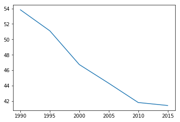

```python
x=UK_df.columns.tolist()[2:]                      #Prepare list of independent variables : Year
y=UK_df.iloc[0,2:].tolist()                       #Prepare lisy of dependent variables : Mortality Rate
plt.plot(x,y)                                     #Create the line graph using plt.plot
plt.show()                                        #Draw the line graph
```

### Bar graphs :

- Very useful for **non continuous** data and help in **comparing** or **contrasting** different **categories** of the data provided.
- Lets draw a Bar plot for Mean Mortality Rate in 2015 for each Super Region.

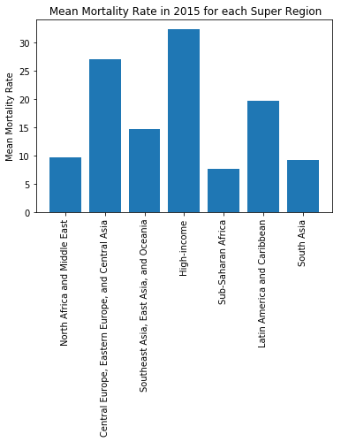

```python
sr_list, sr_mean = [], []                                #Two empty lists for our values
for sr in can_df.Super_Region.unique():                  #Get a unique list of super regions
    sr_list.append(sr)                                   #Append super regions to our list
    #Get the average of mortality rate for each super region
    my_mean = can_df.iloc[:,can_df.columns.get_loc("2015")][can_df.Super_Region== sr].mean()
    sr_mean.append(my_mean)                              #Add those averages to our list

#plt.bar works with numerical values therefore we need to create a list of secqunce to use for our plot
y_pos = range(len(sr_list))
plt.bar(y_pos, sr_mean)                                  #Create the bar graph using plt.bar

plt.xticks(y_pos, sr_list,rotation=90)              #Use plt.xticks to put back super regions names on the x axis
plt.ylabel('Mean Mortality Rate')                   #Label Y axis
plt.title(' Mean Mortality Rate in 2015 for each Super Region')    #Title the graph

plt.show()                                            #Draw the bar graph
```

### PRACTICE: Let's Visualise

Make sure you select correct numerical values

Time : 5 mins

# What we learnt today:

- Load a dataset into a DataFrame
- Exlore the data
- Visualise the data